# R ile Veri Analizinde *Tidyverse* Yaklaşımı

Prof. Dr. Hüseyin Taştan

Yıldız Teknik Üniversitesi

# 1 R’ın Modern bir yorumu: Tidyverse

- [Tidyverse](https://www.tidyverse.org/) modern veri analizi için geliştirilmiş `R` paketler topluluğuna verilen isimdir.
- Bu konuda temel kaynak Garret Grolemund ve Hadley Wickham tarafından yazılan [R for Data Science](https://r4ds.had.co.nz/) kitabıdır.
- Bu kitabın birinci baskısının Türkçe çevirisi için bkz. https://tr.r4ds.hadley.nz/
- Ayrıca diğer kaynaklar için bkz. [*Tidy Data*](https://vita.had.co.nz/papers/tidy-data.pdf) (Hadley Wickham, 2014 JSS), ve [Tidy data Vignette](https://cran.r-project.org/web/packages/tidyr/vignettes/tidy-data.html)

[figure not shown]

Tidyverse R Paketleri

```r
library(tidyverse)
```

- `library(tidyverse)` komutu ile aşağıdaki R paketlerinin tamamı aktif hale gelir:
  - `{ggplot2}`: verilerin görselleştirilmesi
  - `{dplyr}`: verilerin işlenmesi
  - `{tidyr}`: verilerin düzenli (“tidy”) hale getirilmesi
  - `{readr}`: verilerin okunması
  - `{purrr}`: fonksiyonel programlama
  - `{tibble}`: veri çerçevesi (data.frame’in yeni yorumu)
  - `{stringr}`: karakterlerin işlenmesi
  - `{forcats}`: faktör değişkenlerinin işlenmesi

Bu paketlerin yanı sıra Tidyverse yaklaşımıyla uyumla çok sayıda R paketi mevcuttur.

# 2 R “Tidy” veri çerçeveleri

- Bir düzenli (tidy) veri seti standart dikdörtgensel yapıya sahiptir. Ancak sütunlar değişkenleri, satırlar ise gözlemleri göstermelidir. Her veri seti düzenli formatta olmayabilir. Veri analizinden önce düzenli hale getirilmesi gerekebilir.

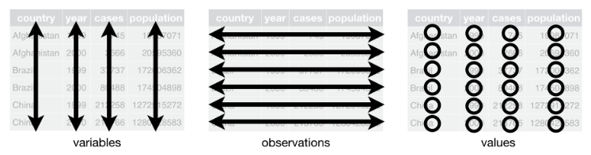

Düzenli (tidy) bir veri setinin yapısı (kaynak: R for Data Science, https://r4ds.had.co.nz/tidy-data.html)

Örnek olarak aşağıdaki veri setini düşünelim:

```r
library(gapminder)
head(gapminder)
```

```
## # A tibble: 6 × 6
##   country     continent  year lifeExp      pop gdpPercap
##   <fct>       <fct>     <int>   <dbl>    <int>     <dbl>
## 1 Afghanistan Asia       1952    28.8  8425333      779.
## 2 Afghanistan Asia       1957    30.3  9240934      821.
## 3 Afghanistan Asia       1962    32.0 10267083      853.
## 4 Afghanistan Asia       1967    34.0 11537966      836.
## 5 Afghanistan Asia       1972    36.1 13079460      740.
## 6 Afghanistan Asia       1977    38.4 14880372      786.
```

`gapminder` Tidyverse jargonunda bir **tibble**’dır. Tibble (ya da `tbl_df`) R veri çerçevesinin daha modern bir yorumu olarak düşünülebilir (detaylar için bkz https://tibble.tidyverse.org/).

`{tibble}` paketindeki `tibble::tibble()` fonksiyonunu kullanarak bir tidy veri seti yaratabiliriz:

```r
tibble(
  x = 1:5,
  y = 1,
  z = x ^ 2 + y
)
```

```
## # A tibble: 5 × 3
##       x     y     z
##   <int> <dbl> <dbl>
## 1     1     1     2
## 2     2     1     5
## 3     3     1    10
## 4     4     1    17
## 5     5     1    26
```

Başka bir örnek:

```r
df <- tibble(
  xvariable = runif(5),
  depvariable = 2+ 5*xvariable + rnorm(5)
)
df
```

```
## # A tibble: 5 × 2
##   xvariable depvariable
##       <dbl>       <dbl>
## 1    0.826         5.99
## 2    0.0539        1.67
## 3    0.397         2.02
## 4    0.585         4.84
## 5    0.558         5.63
```

Tıpkı temel R’daki `data.frame` fonksiyonunda olduğu gibi `tibble` içindeki değişkenlere çeşitli yollarla ulaşabiliriz:

```r
# extract by column name
df$xvariable
```

```
## [1] 0.82560753 0.05388166 0.39738332 0.58539534 0.55819909
```

```r
# extract by column name
df[["xvariable"]]
```

```
## [1] 0.82560753 0.05388166 0.39738332 0.58539534 0.55819909
```

```r
# extract by column position
df[[1]]
```

```
## [1] 0.82560753 0.05388166 0.39738332 0.58539534 0.55819909
```

# 3 `{readr}` Paketi ile Verilerin okutulması

- Tidyverse meta-paketindeki [`{readr}`](https://readr.tidyverse.org/) paketi verilerin okutulmasına ilişkin çeşitli fonksiyonlar içerir.
- `read_` ile başlayan bu fonksiyonlar şunlardır:
  - `read_csv()`: virgülle ayrılmış dosya (comma separated (CSV))
  - `read_tsv()`: tab ile ayrılmış
  - `read_delim()`: ayrılmış (örneğin “;” ya d “|” ile ayrılmış)
  - `read_fwf()`: sabit genişlikli dosya
  - `read_table()`: sütunların boşluklarla ayrıldığı tablo şeklindeki dosyalar
  - `read_log()`: web log dosyaları
- Örnek: `veriler/trveri1.csv` her ne kadar uzantısı csv olsa da sütunların noktalı virgülle ayrıldığı bir dosya. Bu nedenle `read_delim()` kullanılabilir.

```r
tr_veri <- read_delim("Data/trveri1.csv", delim = ";")
```

Fonksiyonun çıktısında hangi değişkenlerin karakter hangilerinin nümerik (double) olarak okunduğunu görebiliyoruz.

```r
tr_veri
```

```
## # A tibble: 12 × 6
##    il       plaka degisken      y2005     y2010     y2015
##    <chr>    <dbl> <chr>         <dbl>     <dbl>     <dbl>
##  1 Istanbul    34 GDPpc         16749    26253     49773
##  2 Istanbul    34 RGDPpc        13986    14384     18602.
##  3 Istanbul    34 GDPpc_USD     12428    17480     18343
##  4 Istanbul    34 population 12000000 13100000  14500000
##  5 Izmir       35 GDPpc         12011    18308     34261
##  6 Izmir       35 RGDPpc         9922    10211.    12927.
##  7 Izmir       35 GDPpc_USD      8912    12190     12626
##  8 Izmir       35 population  3626321  3908672   4140726
##  9 Ankara       6 GDPpc         15392    23997     40679
## 10 Ankara       6 RGDPpc        12910    13019.    15029.
## 11 Ankara       6 GDPpc_USD     11420    15978     14992
## 12 Ankara       6 population  4252588  4711187   5210297
```

- Aynı veri setinin tab ile ayrılmış text dosyası formu:

```r
tr_veri <- read_tsv("Data/trveri1.txt")
tr_veri
```

```
## # A tibble: 12 × 6
##    il       plaka degisken      y2005     y2010     y2015
##    <chr>    <dbl> <chr>         <dbl>     <dbl>     <dbl>
##  1 Istanbul    34 GDPpc         16749    26253     49773
##  2 Istanbul    34 RGDPpc        13986    14384     18602.
##  3 Istanbul    34 GDPpc_USD     12428    17480     18343
##  4 Istanbul    34 population 12000000 13100000  14500000
##  5 Izmir       35 GDPpc         12011    18308     34261
##  6 Izmir       35 RGDPpc         9922    10211.    12927.
##  7 Izmir       35 GDPpc_USD      8912    12190     12626
##  8 Izmir       35 population  3626321  3908672   4140726
##  9 Ankara       6 GDPpc         15392    23997     40679
## 10 Ankara       6 RGDPpc        12910    13019.    15029.
## 11 Ankara       6 GDPpc_USD     11420    15978     14992
## 12 Ankara       6 population  4252588  4711187   5210297
```

- Bu veri seti düzenli bir yapıda değildir. Satırlarda değişkenler, sütunlarda ise yıllar yer almaktadır. Verileri `{tidyr}` paketindeki fonksiyonları kullanarak yeniden düzenleyebiliriz. Bunu daha sonra göreceğiz.
- Dosyada yer alan değişkenlerin türlerini de belirtmek mümkündür. Kullanım rehberindeki örneğe bakalım:

```r
mtcars <- read_csv(readr_example("mtcars.csv"), col_types =
  cols(
    mpg = col_double(),
    cyl = col_integer(),
    disp = col_double(),
    hp = col_integer(),
    drat = col_double(),
    vs = col_integer(),
    wt = col_double(),
    qsec = col_double(),
    am = col_integer(),
    gear = col_integer(),
    carb = col_integer()
  )
)
```

```r
str(mtcars)
```

```
## spc_tbl_ [32 × 11] (S3: spec_tbl_df/tbl_df/tbl/data.frame)
##  $ mpg : num [1:32] 21 21 22.8 21.4 18.7 18.1 14.3 24.4 22.8 19.2 ...
##  $ cyl : int [1:32] 6 6 4 6 8 6 8 4 4 6 ...
##  $ disp: num [1:32] 160 160 108 258 360 ...
##  $ hp  : int [1:32] 110 110 93 110 175 105 245 62 95 123 ...
##  $ drat: num [1:32] 3.9 3.9 3.85 3.08 3.15 2.76 3.21 3.69 3.92 3.92 ...
##  $ wt  : num [1:32] 2.62 2.88 2.32 3.21 3.44 ...
##  $ qsec: num [1:32] 16.5 17 18.6 19.4 17 ...
##  $ vs  : int [1:32] 0 0 1 1 0 1 0 1 1 1 ...
##  $ am  : int [1:32] 1 1 1 0 0 0 0 0 0 0 ...
##  $ gear: int [1:32] 4 4 4 3 3 3 3 4 4 4 ...
##  $ carb: int [1:32] 4 4 1 1 2 1 4 2 2 4 ...
##  - attr(*, "spec")=
##   .. cols(
##   ..   mpg = col_double(),
##   ..   cyl = col_integer(),
##   ..   disp = col_double(),
##   ..   hp = col_integer(),
##   ..   drat = col_double(),
##   ..   wt = col_double(),
##   ..   qsec = col_double(),
##   ..   vs = col_integer(),
##   ..   am = col_integer(),
##   ..   gear = col_integer(),
##   ..   carb = col_integer()
##   .. )
##  - attr(*, "problems")=<externalptr>
```

- Excel dosyalarının okutulmasında [`{readxl}`](https://readxl.tidyverse.org/) paketi kullanılabilir. Bunun için paketin ayrıca yüklenmesi gerekir. Örnek:

```r
library(readxl)
tr_veri <- read_xlsx("Data/trveri1.xlsx")
tr_veri
```

```
## # A tibble: 12 × 6
##    il       plaka degisken       y2005     y2010     y2015
##    <chr>    <dbl> <chr>          <dbl>     <dbl>     <dbl>
##  1 Istanbul    34 GDPpc         16749     26253     49773
##  2 Istanbul    34 RGDPpc        13986     14384     18602.
##  3 Istanbul    34 GDPpc_USD     12428     17480     18343
##  4 Istanbul    34 population 12000000  13100000  14500000
##  5 Izmir       35 GDPpc         12011     18308     34261
##  6 Izmir       35 RGDPpc         9922.    10211.    12927.
##  7 Izmir       35 GDPpc_USD      8912     12190     12626
##  8 Izmir       35 population  3626321   3908672   4140726
##  9 Ankara       6 GDPpc         15392     23997     40679
## 10 Ankara       6 RGDPpc        12910.    13019.    15029.
## 11 Ankara       6 GDPpc_USD     11420     15978     14992
## 12 Ankara       6 population  4252588   4711187   5210297
```

- Stata, SPSS, ve SAS veri dosyalarının da okutulması mümkündür. Bunun için [`{haven}`](https://haven.tidyverse.org/) paketinin yüklenmesi gerekir. Interaktif veri yüklemek için bkz. Environment -> Import Dataset -> From Stata, etc.

# 4 `{tidyr}` Paketi ile Verilerin Düzenlenmesi

- veriler çok çeşitli biçimlerde karşımıza çıkabilir. Bir örneğini yukarıda görmüştük.
- Veri düzenlemesine ilişkin çeşitli örnekler:

```r
# düzenli bir veri seti
table1
```

```
## # A tibble: 6 × 4
##   country      year  cases population
##   <chr>       <dbl>  <dbl>      <dbl>
## 1 Afghanistan  1999    745   19987071
## 2 Afghanistan  2000   2666   20595360
## 3 Brazil       1999  37737  172006362
## 4 Brazil       2000  80488  174504898
## 5 China        1999 212258 1272915272
## 6 China        2000 213766 1280428583
```

```r
# satırlarda değişkenler var, yıl aynı ülke için tekrar ediyor
table2
```

```
## # A tibble: 12 × 4
##    country      year type            count
##    <chr>       <dbl> <chr>           <dbl>
##  1 Afghanistan  1999 cases             745
##  2 Afghanistan  1999 population   19987071
##  3 Afghanistan  2000 cases            2666
##  4 Afghanistan  2000 population   20595360
##  5 Brazil       1999 cases           37737
##  6 Brazil       1999 population  172006362
##  7 Brazil       2000 cases           80488
##  8 Brazil       2000 population  174504898
##  9 China        1999 cases          212258
## 10 China        1999 population 1272915272
## 11 China        2000 cases          213766
## 12 China        2000 population 1280428583
```

```r
# değişken (rate) karakter vektörü olarak tanımlı
# ayrıca iki rakamın oranı açıkça yazılmış
table3
```

```
## # A tibble: 6 × 3
##   country      year rate
##   <chr>       <dbl> <chr>
## 1 Afghanistan  1999 745/19987071
## 2 Afghanistan  2000 2666/20595360
## 3 Brazil       1999 37737/172006362
## 4 Brazil       2000 80488/174504898
## 5 China        1999 212258/1272915272
## 6 China        2000 213766/1280428583
```

```r
# sütunlarda değişkenin (cases) yıl ölçümleri var
table4a
```

```
## # A tibble: 3 × 3
##   country     `1999` `2000`
##   <chr>        <dbl>  <dbl>
## 1 Afghanistan    745   2666
## 2 Brazil       37737  80488
## 3 China       212258 213766
```

```r
# sütunlarda değişkenin (population) yıl ölçümleri var
table4b
```

```
## # A tibble: 3 × 3
##   country         `1999`     `2000`
##   <chr>            <dbl>      <dbl>
## 1 Afghanistan   19987071   20595360
## 2 Brazil       172006362  174504898
## 3 China       1272915272 1280428583
```

- Bu veri setlerini nasıl tidy formata dönüştürebiliriz? Tidy formatta aşağıdaki kurallara uyulması gerekmektedir:
1. Her değişken kendi sütununda olmalıdır.
2. Her gözlem kendi satırında olmalıdır.
3. Her değer kendi hücresinde olmalıdır.
- Verilerin yeniden organize edilmesinde [`{tidyr}`](https://tidyr.tidyverse.org/) paketinde yer alan iki fonksiyon çok faydalı olabilir.
  - `pivot_longer()`: verileri yeniden düzenleyerek uzun forma dönüştürür
  - `pivot_wider()`: verileri yeniden düzenleyerek geniş forma dönüştürür.
- Örnek: `table4a` ve `table4b` verilerini uzun forma dönüştürelim:

```r
pivot_longer(table4a, cols = 2:3, names_to = "year", values_to = "cases")
```

```
## # A tibble: 6 × 3
##   country     year   cases
##   <chr>       <chr>  <dbl>
## 1 Afghanistan 1999     745
## 2 Afghanistan 2000    2666
## 3 Brazil      1999   37737
## 4 Brazil      2000   80488
## 5 China       1999  212258
## 6 China       2000  213766
```

```r
pivot_longer(table4b, cols = 2:3, names_to = "year", values_to = "population")
```

```
## # A tibble: 6 × 3
##   country     year  population
##   <chr>       <chr>      <dbl>
## 1 Afghanistan 1999    19987071
## 2 Afghanistan 2000    20595360
## 3 Brazil      1999   172006362
## 4 Brazil      2000   174504898
## 5 China       1999  1272915272
## 6 China       2000  1280428583
```

- Örnek: `table2` verilerini geniş forma dönüştürelim:

```r
pivot_wider(table2, names_from = "type", values_from = "count")
```

```
## # A tibble: 6 × 4
##   country      year  cases population
##   <chr>       <dbl>  <dbl>      <dbl>
## 1 Afghanistan  1999    745   19987071
## 2 Afghanistan  2000   2666   20595360
## 3 Brazil       1999  37737  172006362
## 4 Brazil       2000  80488  174504898
## 5 China        1999 212258 1272915272
## 6 China        2000 213766 1280428583
```

- Örnek: `tr_veri` verisini düzenli hale getirelim:

```r
tr_veri
```

```
## # A tibble: 12 × 6
##    il       plaka degisken       y2005     y2010     y2015
##    <chr>    <dbl> <chr>          <dbl>     <dbl>     <dbl>
##  1 Istanbul    34 GDPpc         16749     26253     49773
##  2 Istanbul    34 RGDPpc        13986     14384     18602.
##  3 Istanbul    34 GDPpc_USD     12428     17480     18343
##  4 Istanbul    34 population 12000000  13100000  14500000
##  5 Izmir       35 GDPpc         12011     18308     34261
##  6 Izmir       35 RGDPpc         9922.    10211.    12927.
##  7 Izmir       35 GDPpc_USD      8912     12190     12626
##  8 Izmir       35 population  3626321   3908672   4140726
##  9 Ankara       6 GDPpc         15392     23997     40679
## 10 Ankara       6 RGDPpc        12910.    13019.    15029.
## 11 Ankara       6 GDPpc_USD     11420     15978     14992
## 12 Ankara       6 population  4252588   4711187   5210297
```

```r
pivot_longer(tr_veri,
             cols = c(`y2005`, `y2010`, `y2015`),
             names_to = "yil",
             values_to = "olcum")
```

```
## # A tibble: 36 × 5
##    il       plaka degisken   yil       olcum
##    <chr>    <dbl> <chr>      <chr>     <dbl>
##  1 Istanbul    34 GDPpc      y2005    16749
##  2 Istanbul    34 GDPpc      y2010    26253
##  3 Istanbul    34 GDPpc      y2015    49773
##  4 Istanbul    34 RGDPpc     y2005    13986
##  5 Istanbul    34 RGDPpc     y2010    14384
##  6 Istanbul    34 RGDPpc     y2015    18602.
##  7 Istanbul    34 GDPpc_USD  y2005    12428
##  8 Istanbul    34 GDPpc_USD  y2010    17480
##  9 Istanbul    34 GDPpc_USD  y2015    18343
## 10 Istanbul    34 population y2005 12000000
## # ℹ 26 more rows
```

Bu veri setinde satırlarda değişkenler var. Ayrıca `yil` değişkeninin önünde “y” karakteri var. Bunu aşağıdaki gibi düzeltebiliriz:

```r
tr_veri_uzun <- pivot_longer(tr_veri,
                             cols = c(`y2005`, `y2010`, `y2015`),
                             names_to = "yil",
                             values_to = "olcum",
                             names_prefix = "y"
                             )
tr_veri_uzun
```

```
## # A tibble: 36 × 5
##    il       plaka degisken   yil       olcum
##    <chr>    <dbl> <chr>      <chr>     <dbl>
##  1 Istanbul    34 GDPpc      2005     16749
##  2 Istanbul    34 GDPpc      2010     26253
##  3 Istanbul    34 GDPpc      2015     49773
##  4 Istanbul    34 RGDPpc     2005     13986
##  5 Istanbul    34 RGDPpc     2010     14384
##  6 Istanbul    34 RGDPpc     2015     18602.
##  7 Istanbul    34 GDPpc_USD  2005     12428
##  8 Istanbul    34 GDPpc_USD  2010     17480
##  9 Istanbul    34 GDPpc_USD  2015     18343
## 10 Istanbul    34 population 2005  12000000
## # ℹ 26 more rows
```

Şimdi `pivot_wider()` ile değişkenleri sütunlara alalım:

```r
pivot_wider(tr_veri_uzun, names_from = "degisken", values_from = "olcum")
```

```
## # A tibble: 9 × 7
##   il       plaka yil   GDPpc RGDPpc GDPpc_USD population
##   <chr>    <dbl> <chr> <dbl>  <dbl>     <dbl>      <dbl>
## 1 Istanbul    34 2005  16749 13986      12428   12000000
## 2 Istanbul    34 2010  26253 14384      17480   13100000
## 3 Istanbul    34 2015  49773 18602.     18343   14500000
## 4 Izmir       35 2005  12011  9922.      8912    3626321
## 5 Izmir       35 2010  18308 10211.     12190    3908672
## 6 Izmir       35 2015  34261 12927.     12626    4140726
## 7 Ankara       6 2005  15392 12910.     11420    4252588
## 8 Ankara       6 2010  23997 13019.     15978    4711187
## 9 Ankara       6 2015  40679 15029.     14992    5210297
```

Birleştirilmiş bu düzenli veri setinde `il` ve `yil` çifti bir gözlemi oluşturur. İstanbul ilinde 2005 yılında sadece bir satır bulunabilir.

## 4.1 Kayıp gözlemler

- `drop_na()`: kayıp gözlemleri sil

```r
df <- tibble(x = c(1, 2, NA),
             y = c("a", NA, "b"))
df
```

```
## # A tibble: 3 × 2
##       x y
##   <dbl> <chr>
## 1     1 a
## 2     2 <NA>
## 3    NA b
```

```r
# tüm NA gözlemleri sil
drop_na(df)
```

```
## # A tibble: 1 × 2
##       x y
##   <dbl> <chr>
## 1     1 a
```

```r
# x sütunundaki NA gözlemleri sil
drop_na(df, x)
```

```
## # A tibble: 2 × 2
##       x y
##   <dbl> <chr>
## 1     1 a
## 2     2 <NA>
```

- `fill()`: kayıp gözlemleri bir önceki ya da bir sonraki doldur. Örnek (help dosyasından):

```r
sales <- tibble::tribble(
  ~quarter, ~year, ~sales,
  "Q1",    2000,    66013,
  "Q2",      NA,    69182,
  "Q3",      NA,    53175,
  "Q4",      NA,    21001,
  "Q1",    2001,    46036,
  "Q2",      NA,    58842,
  "Q3",      NA,    44568,
  "Q4",      NA,    50197,
  "Q1",    2002,    39113,
  "Q2",      NA,    41668,
  "Q3",      NA,    30144,
  "Q4",      NA,    52897,
  "Q1",    2004,    32129,
  "Q2",      NA,    67686,
  "Q3",      NA,    31768,
  "Q4",      NA,    49094
)
sales
```

```
## # A tibble: 16 × 3
##    quarter  year sales
##    <chr>   <dbl> <dbl>
##  1 Q1       2000 66013
##  2 Q2         NA 69182
##  3 Q3         NA 53175
##  4 Q4         NA 21001
##  5 Q1       2001 46036
##  6 Q2         NA 58842
##  7 Q3         NA 44568
##  8 Q4         NA 50197
##  9 Q1       2002 39113
## 10 Q2         NA 41668
## 11 Q3         NA 30144
## 12 Q4         NA 52897
## 13 Q1       2004 32129
## 14 Q2         NA 67686
## 15 Q3         NA 31768
## 16 Q4         NA 49094
```

`sales` veri setinde yıl değerleri sadece değiştiğinde açıkça yazılmış. Aslında NA değil Q1 dönemindeki yıl değerine eşit.

```r
# year değerlerini yukarıdan aşağıya doğru doldur
fill(sales, year)
```

```
## # A tibble: 16 × 3
##    quarter  year sales
##    <chr>   <dbl> <dbl>
##  1 Q1       2000 66013
##  2 Q2       2000 69182
##  3 Q3       2000 53175
##  4 Q4       2000 21001
##  5 Q1       2001 46036
##  6 Q2       2001 58842
##  7 Q3       2001 44568
##  8 Q4       2001 50197
##  9 Q1       2002 39113
## 10 Q2       2002 41668
## 11 Q3       2002 30144
## 12 Q4       2002 52897
## 13 Q1       2004 32129
## 14 Q2       2004 67686
## 15 Q3       2004 31768
## 16 Q4       2004 49094
```

- `replace_na()`: NA yerine belirtilmiş (bilinen) değerleri yaz.

```r
df <- tibble(x = c(1, 2, NA),
             y = c("a", NA, "b"))
df
```

```
## # A tibble: 3 × 2
##       x y
##   <dbl> <chr>
## 1     1 a
## 2     2 <NA>
## 3    NA b
```

```r
# x değişkeninde NA değerleri yerine 0
# y değişkeninde NA değerleri yerine "bilinmiyor" yaz
replace_na(df, list(x = 0, y = "bilinmiyor"))
```

```
## # A tibble: 3 × 2
##       x y
##   <dbl> <chr>
## 1     1 a
## 2     2 bilinmiyor
## 3     0 b
```

- `complete()`: Gizli kayıp gözlemleri açık hale getir.

```r
df <- tibble(il = c("İstanbul", "İstanbul", "Ankara"),
             yil = c(2019, 2020, 2019),
             kfe = c(250, 300, 220))
df
```

```
## # A tibble: 3 × 3
##   il         yil   kfe
##   <chr>    <dbl> <dbl>
## 1 İstanbul  2019   250
## 2 İstanbul  2020   300
## 3 Ankara    2019   220
```

```r
complete(df, il, yil)
```

```
## # A tibble: 4 × 3
##   il         yil   kfe
##   <chr>    <dbl> <dbl>
## 1 Ankara    2019   220
## 2 Ankara    2020    NA
## 3 İstanbul  2019   250
## 4 İstanbul  2020   300
```

## 4.2 Hücrelerin ayrılması veya birleştirilmesi

- `table3` veri setinde `rate` değişkeni oran karakteri ile tanımlanmıştı:

```r
table3
```

```
## # A tibble: 6 × 3
##   country      year rate
##   <chr>       <dbl> <chr>
## 1 Afghanistan  1999 745/19987071
## 2 Afghanistan  2000 2666/20595360
## 3 Brazil       1999 37737/172006362
## 4 Brazil       2000 80488/174504898
## 5 China        1999 212258/1272915272
## 6 China        2000 213766/1280428583
```

Bu haliyle analizde kullanılması mümkün değildir.

- Bir sütunun hücrelerini ayırmak için `separate()` fonksiyonu kullanılabilir:

```r
separate(table3, col = rate, sep = "/", into = c("cases", "population"))
```

```
## # A tibble: 6 × 4
##   country      year cases  population
##   <chr>       <dbl> <chr>  <chr>
## 1 Afghanistan  1999 745    19987071
## 2 Afghanistan  2000 2666   20595360
## 3 Brazil       1999 37737  172006362
## 4 Brazil       2000 80488  174504898
## 5 China        1999 212258 1272915272
## 6 China        2000 213766 1280428583
```

- Hücreler ayrılıp satır haline de getirilebilir:

```r
separate_rows(table3, rate, sep = "/")
```

```
## # A tibble: 12 × 3
##    country      year rate
##    <chr>       <dbl> <chr>
##  1 Afghanistan  1999 745
##  2 Afghanistan  1999 19987071
##  3 Afghanistan  2000 2666
##  4 Afghanistan  2000 20595360
##  5 Brazil       1999 37737
##  6 Brazil       1999 172006362
##  7 Brazil       2000 80488
##  8 Brazil       2000 174504898
##  9 China        1999 212258
## 10 China        1999 1272915272
## 11 China        2000 213766
## 12 China        2000 1280428583
```

- Alıştırma: Yukarıdaki veri seti “düzenli” formda mıdır? Değilse nasıl düzenli hale getirilebilir? Cevap:

```r
table3_a <- separate_rows(table3, rate, sep = "/")
table3_a <- table3_a |> group_by(country, year) |>
  mutate(rowno = row_number())
table3_a
```

```
## # A tibble: 12 × 4
## # Groups:   country, year [6]
##    country      year rate       rowno
##    <chr>       <dbl> <chr>      <int>
##  1 Afghanistan  1999 745            1
##  2 Afghanistan  1999 19987071       2
##  3 Afghanistan  2000 2666           1
##  4 Afghanistan  2000 20595360       2
##  5 Brazil       1999 37737          1
##  6 Brazil       1999 172006362      2
##  7 Brazil       2000 80488          1
##  8 Brazil       2000 174504898      2
##  9 China        1999 212258         1
## 10 China        1999 1272915272     2
## 11 China        2000 213766         1
## 12 China        2000 1280428583     2
```

```r
table3_b <- pivot_wider(table3_a, names_from = "rowno", values_from = "rate")
table3_b
```

```
## # A tibble: 6 × 4
## # Groups:   country, year [6]
##   country      year `1`    `2`
##   <chr>       <dbl> <chr>  <chr>
## 1 Afghanistan  1999 745    19987071
## 2 Afghanistan  2000 2666   20595360
## 3 Brazil       1999 37737  172006362
## 4 Brazil       2000 80488  174504898
## 5 China        1999 212258 1272915272
## 6 China        2000 213766 1280428583
```

```r
table3_b |> rename(cases = `1`, population = `2`)
```

```
## # A tibble: 6 × 4
## # Groups:   country, year [6]
##   country      year cases  population
##   <chr>       <dbl> <chr>  <chr>
## 1 Afghanistan  1999 745    19987071
## 2 Afghanistan  2000 2666   20595360
## 3 Brazil       1999 37737  172006362
## 4 Brazil       2000 80488  174504898
## 5 China        1999 212258 1272915272
## 6 China        2000 213766 1280428583
```

```r
# sütun isimlerinin önüne bir kelime eklenebilir:
pivot_wider(table3_a,
            names_from = "rowno",
            values_from = "rate",
            names_prefix = "variable")
```

```
## # A tibble: 6 × 4
## # Groups:   country, year [6]
##   country      year variable1 variable2
##   <chr>       <dbl> <chr>     <chr>
## 1 Afghanistan  1999 745       19987071
## 2 Afghanistan  2000 2666      20595360
## 3 Brazil       1999 37737     172006362
## 4 Brazil       2000 80488     174504898
## 5 China        1999 212258    1272915272
## 6 China        2000 213766    1280428583
```

- Bazı durumlarda hücrelerin birleştirilmesi gerekebilir. Örneğin,

```r
# century ve year değişkenlerinin hücrelerini birleştirmek isteyebiliriz
table5
```

```
## # A tibble: 6 × 4
##   country     century year  rate
##   <chr>       <chr>   <chr> <chr>
## 1 Afghanistan 19      99    745/19987071
## 2 Afghanistan 20      00    2666/20595360
## 3 Brazil      19      99    37737/172006362
## 4 Brazil      20      00    80488/174504898
## 5 China       19      99    212258/1272915272
## 6 China       20      00    213766/1280428583
```

```r
table5a <- unite(table5, century, year, col = "year", sep = "")
table5a
```

```
## # A tibble: 6 × 3
##   country     year  rate
##   <chr>       <chr> <chr>
## 1 Afghanistan 1999  745/19987071
## 2 Afghanistan 2000  2666/20595360
## 3 Brazil      1999  37737/172006362
## 4 Brazil      2000  80488/174504898
## 5 China       1999  212258/1272915272
## 6 China       2000  213766/1280428583
```

```r
# rate sütununu ayır
separate(table5a, col = rate, sep = "/", into = c("cases", "population"), convert = TRUE)
```

```
## # A tibble: 6 × 4
##   country     year   cases population
##   <chr>       <chr>  <int>      <int>
## 1 Afghanistan 1999     745   19987071
## 2 Afghanistan 2000    2666   20595360
## 3 Brazil      1999   37737  172006362
## 4 Brazil      2000   80488  174504898
## 5 China       1999  212258 1272915272
## 6 China       2000  213766 1280428583
```

# 5 `{dplyr}` Paketi ile Verilerin Manipülasyonu

- Verilerin işlenmesi, özetlenmesi, birleştirilmesi, yeni veriler oluşturulması ve benzeri işlemler için çeşitli fonksiyonlar içerir.
- Temel `{dplyr}` fonksiyonları şunlardır:
  - `filter()`: belirli mantıksal ölçütlere uygun alt kümelerin oluşturulması
  - `select()`: sütunların (değişkenlerin) seçimi
  - `mutate()`: yeni değişken oluşturma
  - `summarize()`: verilerin özetlenmesi
  - `arrange()`: verilerin sıralanması
- Tüm işlemler, satır seçimi, sütun seçimi, yeni değişken oluşturma, özetleme, sıralama, veri içindeki grup değişken(ler)ine göre yapılabilir. Bunun için `group_by()` fonksiyonu kullanılır.

## 5.1 `filter()`: gözlemlerin filtrelenmesi

- `dplyr::filter()` fonksiyonu ile satırlara göre alt kümeler oluşturabiliriz.
- Belirttiğimiz kriterlere uygun gözlemlerden oluşan yeni veri çerçeveleri veya tablolar oluşturabiliriz.

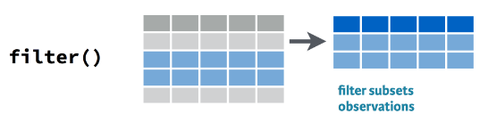

- **Örnek** `gapminder` ülke veri setinde Türkiye’nin gözlemlerini almak istediğimizi düşünelim. Veri setini incelediğimizde Türkiye’nin 1573 ile 1584 satırları arasında yer aldığını görüyoruz. Bu bilgiden hareketle Türkiye veri setini aşağıdaki gibi oluşturabiliriz:

```r
library(tidyverse)
library(gapminder)
(turkey <- gapminder[1573:1584,])
```

```
## # A tibble: 12 × 6
##    country continent  year lifeExp      pop gdpPercap
##    <fct>   <fct>     <int>   <dbl>    <int>     <dbl>
##  1 Turkey  Europe     1952    43.6 22235677     1969.
##  2 Turkey  Europe     1957    48.1 25670939     2219.
##  3 Turkey  Europe     1962    52.1 29788695     2323.
##  4 Turkey  Europe     1967    54.3 33411317     2826.
##  5 Turkey  Europe     1972    57.0 37492953     3451.
##  6 Turkey  Europe     1977    59.5 42404033     4269.
##  7 Turkey  Europe     1982    61.0 47328791     4241.
##  8 Turkey  Europe     1987    63.1 52881328     5089.
##  9 Turkey  Europe     1992    66.1 58179144     5678.
## 10 Turkey  Europe     1997    68.8 63047647     6601.
## 11 Turkey  Europe     2002    70.8 67308928     6508.
## 12 Turkey  Europe     2007    71.8 71158647     8458.
```

- Satır numaralarını kullanarak verileri çekmek hata olasılığını arttırdığı için tercih edilmemelidir.
- Bunun yerine `dplyr::filter()` fonksiyonunu kullanabiliriz. Bu fonksiyonun girdisi verilerin satırlarına uygulanan mantıksal ifadelerdir. Örneğin:

```r
filter(gapminder, country == "Turkey")
```

```
## # A tibble: 12 × 6
##    country continent  year lifeExp      pop gdpPercap
##    <fct>   <fct>     <int>   <dbl>    <int>     <dbl>
##  1 Turkey  Europe     1952    43.6 22235677     1969.
##  2 Turkey  Europe     1957    48.1 25670939     2219.
##  3 Turkey  Europe     1962    52.1 29788695     2323.
##  4 Turkey  Europe     1967    54.3 33411317     2826.
##  5 Turkey  Europe     1972    57.0 37492953     3451.
##  6 Turkey  Europe     1977    59.5 42404033     4269.
##  7 Turkey  Europe     1982    61.0 47328791     4241.
##  8 Turkey  Europe     1987    63.1 52881328     5089.
##  9 Turkey  Europe     1992    66.1 58179144     5678.
## 10 Turkey  Europe     1997    68.8 63047647     6601.
## 11 Turkey  Europe     2002    70.8 67308928     6508.
## 12 Turkey  Europe     2007    71.8 71158647     8458.
```

- Bu fonksiyonun kullanımı baz `R`’daki `subset()` fonksiyonuna benzemektedir.
- `filter()` fonksiyonu çoklu ifadelerin kullanılmasına izin verir. Örneğin, Türkiye’nin 2000 sonrası verileri için aşağıdaki komutu kullanabiliriz:

```r
filter(gapminder, country == "Turkey", year>2000)
```

```
## # A tibble: 2 × 6
##   country continent  year lifeExp      pop gdpPercap
##   <fct>   <fct>     <int>   <dbl>    <int>     <dbl>
## 1 Turkey  Europe     2002    70.8 67308928     6508.
## 2 Turkey  Europe     2007    71.8 71158647     8458.
```

- **Örnek**: Türkiye ve Brezilya’nın 2000 sonrası gözlemlerini içeren bir tablo oluştur:

```r
filter(gapminder, country %in% c("Turkey","Brazil"), year>2000)
```

```
## # A tibble: 4 × 6
##   country continent  year lifeExp       pop gdpPercap
##   <fct>   <fct>     <int>   <dbl>     <int>     <dbl>
## 1 Brazil  Americas   2002    71.0 179914212     8131.
## 2 Brazil  Americas   2007    72.4 190010647     9066.
## 3 Turkey  Europe     2002    70.8  67308928     6508.
## 4 Turkey  Europe     2007    71.8  71158647     8458.
```

## 5.2 `select()`: değişkenlerin seçimi

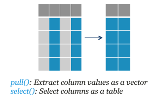

`select()` fonksiyonu

- Sütunlardan (değişkenlerden) hareketle yeni bir tablo (tibble) oluşturmak istersek `dplyr::select()` fonksiyonunu kullanabiliriz.
- ***Örnek** `mtcars` veri setinde `mpg`, `cyl`, `hp` değişkenlerinden oluşan bir tablo oluştur

```r
mtcars
```

```
## # A tibble: 32 × 11
##      mpg   cyl  disp    hp  drat    wt  qsec    vs    am  gear  carb
##    <dbl> <int> <dbl> <int> <dbl> <dbl> <dbl> <int> <int> <int> <int>
##  1  21       6  160    110  3.9   2.62  16.5     0     1     4     4
##  2  21       6  160    110  3.9   2.88  17.0     0     1     4     4
##  3  22.8     4  108     93  3.85  2.32  18.6     1     1     4     1
##  4  21.4     6  258    110  3.08  3.22  19.4     1     0     3     1
##  5  18.7     8  360    175  3.15  3.44  17.0     0     0     3     2
##  6  18.1     6  225    105  2.76  3.46  20.2     1     0     3     1
##  7  14.3     8  360    245  3.21  3.57  15.8     0     0     3     4
##  8  24.4     4  147.    62  3.69  3.19  20       1     0     4     2
##  9  22.8     4  141.    95  3.92  3.15  22.9     1     0     4     2
## 10  19.2     6  168.   123  3.92  3.44  18.3     1     0     4     4
## # ℹ 22 more rows
```

```r
# dplyr::select() can clash with MASS::select()
library(dplyr)
mtcars2 <- dplyr::select(mtcars, mpg, cyl, hp)
mtcars2
```

```
## # A tibble: 32 × 3
##      mpg   cyl    hp
##    <dbl> <int> <int>
##  1  21       6   110
##  2  21       6   110
##  3  22.8     4    93
##  4  21.4     6   110
##  5  18.7     8   175
##  6  18.1     6   105
##  7  14.3     8   245
##  8  24.4     4    62
##  9  22.8     4    95
## 10  19.2     6   123
## # ℹ 22 more rows
```

- `filter()` komutu ile birlikte kullanılabilir.
- **Örnek**: `gapminder` veri setinde Türkiye için sadece yıl, yaşam beklentisi ve kişi başına GDP değişkenlerinden oluşan bir veri çerçevesi oluştur:

```r
gapminder |> filter(country == "Turkey") |>
  select(year, lifeExp, gdpPercap)
```

```
## # A tibble: 12 × 3
##     year lifeExp gdpPercap
##    <int>   <dbl>     <dbl>
##  1  1952    43.6     1969.
##  2  1957    48.1     2219.
##  3  1962    52.1     2323.
##  4  1967    54.3     2826.
##  5  1972    57.0     3451.
##  6  1977    59.5     4269.
##  7  1982    61.0     4241.
##  8  1987    63.1     5089.
##  9  1992    66.1     5678.
## 10  1997    68.8     6601.
## 11  2002    70.8     6508.
## 12  2007    71.8     8458.
```

- **(pipe) işlemcisi %>% (magrittr paketi) veya |> (R native)** : bu işlemciyi kullanarak `f(g(x))` gibi bir işlemi `x %>% g() %>% f()` şeklinde yazabiliriz. Böylece yazdığımız programlar daha basit ve anlaşılır olabilir.
- Önceki örnekte `gapminder` veri seti önce `filter()` fonksiyonuna gönderilerek Türkiye seçildi. Sonraki `%>%` işlemi ile `select()` fonksiyonuna gönderildi ve sütunlar seçildi. Aynı kodu şöyle de yazabilirdik:

```r
select(filter(gapminder, country == "Turkey"), year, lifeExp, gdpPercap)
```

```
## # A tibble: 12 × 3
##     year lifeExp gdpPercap
##    <int>   <dbl>     <dbl>
##  1  1952    43.6     1969.
##  2  1957    48.1     2219.
##  3  1962    52.1     2323.
##  4  1967    54.3     2826.
##  5  1972    57.0     3451.
##  6  1977    59.5     4269.
##  7  1982    61.0     4241.
##  8  1987    63.1     5089.
##  9  1992    66.1     5678.
## 10  1997    68.8     6601.
## 11  2002    70.8     6508.
## 12  2007    71.8     8458.
```

- **Örnek**: Türkiye ve Brezilya için 2000 sonrasında kişi başına GDP değişkenini içeren bir tablo oluştur:

```r
gapminder  |>  filter(country %in% c("Turkey","Brazil"), year>2000) |>
  select(year, country, gdpPercap)
```

```
## # A tibble: 4 × 3
##    year country gdpPercap
##   <int> <fct>       <dbl>
## 1  2002 Brazil      8131.
## 2  2007 Brazil      9066.
## 3  2002 Turkey      6508.
## 4  2007 Turkey      8458.
```

- **Alıştırma**: Önceki örnekteki tabloyu sadece baz R fonksiyonlarını kullanarak oluşturunuz.
- **Çözüm**: `R`’da bir görevi yerine getirmenin birden çok yolu olabilir. Bir çözüm:

```r
gapminder[gapminder$country  %in% c("Turkey", "Brazil") & gapminder$year>2000, c("year", "gdpPercap")]
```

```
## # A tibble: 4 × 2
##    year gdpPercap
##   <int>     <dbl>
## 1  2002     8131.
## 2  2007     9066.
## 3  2002     6508.
## 4  2007     8458.
```

- Eğer bir sütunu alıp atomik bir vektör oluşturmak istersek `pull()` fonksiyonunu kullanabiliriz. Örneğin, `gapminder` veri setindeki ülkelerin isimlerini içeren bir karakter vektörü uluşturalım:

```r
ulkeler <- unique(pull(gapminder, country))
head(ulkeler)
```

```
## [1] Afghanistan Albania     Algeria     Angola      Argentina   Australia
## 142 Levels: Afghanistan Albania Algeria Angola Argentina Australia ... Zimbabwe
```

- Sütun seçimine yardımcı olabilecek fonksiyonlar:
  - `contains()`: bir ifadeyi içeren sütunları seçer
  - `ends_with()`: belirli bir ifade ile biten sütunları seçer
  - `starts_with()`: belirli bir ifadeyle başlayan sütunları seçer
  - `matches()`: bir ifadeyle eşleşen sütunları seçer

## 5.3 `mutate()`: yeni değişken oluşturma

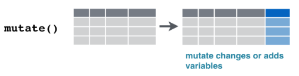

- `dplyr::mutate()` fonksiyonu ile veri setine yeni değişkenler (sütunlar) ekleyebiliriz.
- `mutate()` içinde kullanılan fonksiyonlar vektörleştirilmiş olmalıdır; yani hem girdi hem de çıktı vektör olmalıdır.
- **Örnek**: Kişi başına GDP’nin doğal logaritmasının ayrı bir değişen olarak veri setine eklenmesi:

```r
mutate(gapminder, lgdppc = log(gdpPercap))  |>
  head(5)
```

```
## # A tibble: 5 × 7
##   country     continent  year lifeExp      pop gdpPercap lgdppc
##   <fct>       <fct>     <int>   <dbl>    <int>     <dbl>  <dbl>
## 1 Afghanistan Asia       1952    28.8  8425333      779.   6.66
## 2 Afghanistan Asia       1957    30.3  9240934      821.   6.71
## 3 Afghanistan Asia       1962    32.0 10267083      853.   6.75
## 4 Afghanistan Asia       1967    34.0 11537966      836.   6.73
## 5 Afghanistan Asia       1972    36.1 13079460      740.   6.61
```

- **Örnek**: Veri setinde kişi başına GDP değerleri var ancak toplam GDP yok. Nüfus bilgisini kullanarak toplam ülke GDP değerlerini oluşturunuz.

```r
mutate(gapminder, gdp = gdpPercap*pop )  |>
  select(year, country, gdpPercap, pop, gdp) |>
  head(5)
```

```
## # A tibble: 5 × 5
##    year country     gdpPercap      pop         gdp
##   <int> <fct>           <dbl>    <int>       <dbl>
## 1  1952 Afghanistan      779.  8425333 6567086330.
## 2  1957 Afghanistan      821.  9240934 7585448670.
## 3  1962 Afghanistan      853. 10267083 8758855797.
## 4  1967 Afghanistan      836. 11537966 9648014150.
## 5  1972 Afghanistan      740. 13079460 9678553274.
```

- `mutate()` ile ilişkili diğer fonksiyonlar:
  - `transmute()`: yeni değişkenler oluşturur ve mevcut değişkenleri siler.
  - `mutate_all()`: bir fonksiyonu tüm sütunlara uygular
  - `mutate_if()`: sadece kritere uyan sütunlara bir fonksiyonu uygular
  - `mutate_at()`: bir fonksiyonu belirtilmiş sütunlara uygular
- **Örnekler**

```r
df <- tibble(x = 1:5,
             y = 20:16,
             z = letters[1:5])
df
```

```
## # A tibble: 5 × 3
##       x     y z
##   <int> <int> <chr>
## 1     1    20 a
## 2     2    19 b
## 3     3    18 c
## 4     4    17 d
## 5     5    16 e
```

```r
# transmute() drops variables after mutating
df  |> transmute(w = x*y)
```

```
## # A tibble: 5 × 1
##       w
##   <int>
## 1    20
## 2    38
## 3    54
## 4    68
## 5    80
```

```r
# nümerik sütunların doğal logaritmasını ve 10 tabanına göre
# logaritmasını al
# çoklu dönüştürmeler list() içinde belirtilmeli
df |> mutate_if(is.numeric, list(ln = log, log10 = log10))
```

```
## # A tibble: 5 × 7
##       x     y z      x_ln  y_ln x_log10 y_log10
##   <int> <int> <chr> <dbl> <dbl>   <dbl>   <dbl>
## 1     1    20 a     0      3.00   0        1.30
## 2     2    19 b     0.693  2.94   0.301    1.28
## 3     3    18 c     1.10   2.89   0.477    1.26
## 4     4    17 d     1.39   2.83   0.602    1.23
## 5     5    16 e     1.61   2.77   0.699    1.20
```

```r
# character değişkenin varsa factor değişkenine dönüştür
df |> mutate_if(is.character, as.factor)
```

```
## # A tibble: 5 × 3
##       x     y z
##   <int> <int> <fct>
## 1     1    20 a
## 2     2    19 b
## 3     3    18 c
## 4     4    17 d
## 5     5    16 e
```

```r
# sadece x ve y'nin karelerini ayrı sütun olarak ekle
df |> mutate_at(c("x", "y"), list(sq = function(x) x^2))
```

```
## # A tibble: 5 × 5
##       x     y z      x_sq  y_sq
##   <int> <int> <chr> <dbl> <dbl>
## 1     1    20 a         1   400
## 2     2    19 b         4   361
## 3     3    18 c         9   324
## 4     4    17 d        16   289
## 5     5    16 e        25   256
```

- `mutate()` içinde kullanılan fonksiyonları vektörize olması gerekir. Yani bir vektör girdisine karşılık bir vektör çıktısı hesaplanır. Bu fonksiyonlardan bazıları şunlardır:
  - `dplyr::lag()`: bir vektörün gecikmesini alır. `stats::lag()` ile karıştırılmamalıdır.
  - `dplyr::lead()`: bir vektörün öncü değerlerini oluşturur.
  - kümülatif aritmetik işlemler: `cumall()`, `cumany()`, `cummax()`, `cummean()`, `cummin()`, `cumprod()`, `cumsum()`
  - sıralamalar: `min_rank()`, `percent_rank()`, `row_number()`, `cume_dist()`
  - matematiksel işlemler: `+`, `-`, `*`, `/`, `^`, `%%`, `log`, `log10`, …
  - mantıksal işlemler: `==`, `<`, `<=`, `>`, `>=`, `!=`, `between()`, `near()`
  - `if_else()`: koşullu işlemleri eleman bazında uygular
  - `case_when()`: çoklu if-else
  - `na_if()`: NA değerleri yerine belirli değerleri yaz

## 5.4 `arrange()`: verilerin sıralanması

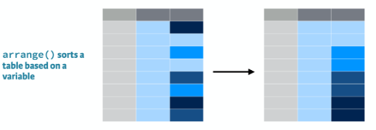

- Veri setinin satırlarının (gözlemlerin) sıralanmasında `dplyr::arrange()` fonksiyonu kullanılabilir.
- **Örnek**: `gapminder` veri setini yıla göre sırala.

```r
arrange(gapminder, year)
```

```
## # A tibble: 1,704 × 6
##    country     continent  year lifeExp      pop gdpPercap
##    <fct>       <fct>     <int>   <dbl>    <int>     <dbl>
##  1 Afghanistan Asia       1952    28.8  8425333      779.
##  2 Albania     Europe     1952    55.2  1282697     1601.
##  3 Algeria     Africa     1952    43.1  9279525     2449.
##  4 Angola      Africa     1952    30.0  4232095     3521.
##  5 Argentina   Americas   1952    62.5 17876956     5911.
##  6 Australia   Oceania    1952    69.1  8691212    10040.
##  7 Austria     Europe     1952    66.8  6927772     6137.
##  8 Bahrain     Asia       1952    50.9   120447     9867.
##  9 Bangladesh  Asia       1952    37.5 46886859      684.
## 10 Belgium     Europe     1952    68    8730405     8343.
## # ℹ 1,694 more rows
```

Default olarak küçükten büyüğe sıraladı. Büyükten küçüğe sıralamak istersek:

```r
arrange(gapminder, desc(year))
```

```
## # A tibble: 1,704 × 6
##    country     continent  year lifeExp       pop gdpPercap
##    <fct>       <fct>     <int>   <dbl>     <int>     <dbl>
##  1 Afghanistan Asia       2007    43.8  31889923      975.
##  2 Albania     Europe     2007    76.4   3600523     5937.
##  3 Algeria     Africa     2007    72.3  33333216     6223.
##  4 Angola      Africa     2007    42.7  12420476     4797.
##  5 Argentina   Americas   2007    75.3  40301927    12779.
##  6 Australia   Oceania    2007    81.2  20434176    34435.
##  7 Austria     Europe     2007    79.8   8199783    36126.
##  8 Bahrain     Asia       2007    75.6    708573    29796.
##  9 Bangladesh  Asia       2007    64.1 150448339     1391.
## 10 Belgium     Europe     2007    79.4  10392226    33693.
## # ℹ 1,694 more rows
```

- **Örnek**: Yılı artan, ülkeleri alfabetik olacak şekilde satırları yeniden düzenle:

```r
arrange(gapminder, year, country)
```

```
## # A tibble: 1,704 × 6
##    country     continent  year lifeExp      pop gdpPercap
##    <fct>       <fct>     <int>   <dbl>    <int>     <dbl>
##  1 Afghanistan Asia       1952    28.8  8425333      779.
##  2 Albania     Europe     1952    55.2  1282697     1601.
##  3 Algeria     Africa     1952    43.1  9279525     2449.
##  4 Angola      Africa     1952    30.0  4232095     3521.
##  5 Argentina   Americas   1952    62.5 17876956     5911.
##  6 Australia   Oceania    1952    69.1  8691212    10040.
##  7 Austria     Europe     1952    66.8  6927772     6137.
##  8 Bahrain     Asia       1952    50.9   120447     9867.
##  9 Bangladesh  Asia       1952    37.5 46886859      684.
## 10 Belgium     Europe     1952    68    8730405     8343.
## # ℹ 1,694 more rows
```

- **Örnek**: Ülkeler alfabetik, yıl artan:

```r
arrange(gapminder, country, year)
```

```
## # A tibble: 1,704 × 6
##    country     continent  year lifeExp      pop gdpPercap
##    <fct>       <fct>     <int>   <dbl>    <int>     <dbl>
##  1 Afghanistan Asia       1952    28.8  8425333      779.
##  2 Afghanistan Asia       1957    30.3  9240934      821.
##  3 Afghanistan Asia       1962    32.0 10267083      853.
##  4 Afghanistan Asia       1967    34.0 11537966      836.
##  5 Afghanistan Asia       1972    36.1 13079460      740.
##  6 Afghanistan Asia       1977    38.4 14880372      786.
##  7 Afghanistan Asia       1982    39.9 12881816      978.
##  8 Afghanistan Asia       1987    40.8 13867957      852.
##  9 Afghanistan Asia       1992    41.7 16317921      649.
## 10 Afghanistan Asia       1997    41.8 22227415      635.
## # ℹ 1,694 more rows
```

- `filter()` ve `arrange()` birlikte kullanılabilir. Örneğin:

```r
gapminder |>
  filter(year==2007, continent=="Americas") |>
  arrange(lifeExp)
```

```
## # A tibble: 25 × 6
##    country             continent  year lifeExp       pop gdpPercap
##    <fct>               <fct>     <int>   <dbl>     <int>     <dbl>
##  1 Haiti               Americas   2007    60.9   8502814     1202.
##  2 Bolivia             Americas   2007    65.6   9119152     3822.
##  3 Trinidad and Tobago Americas   2007    69.8   1056608    18009.
##  4 Honduras            Americas   2007    70.2   7483763     3548.
##  5 Guatemala           Americas   2007    70.3  12572928     5186.
##  6 Peru                Americas   2007    71.4  28674757     7409.
##  7 Paraguay            Americas   2007    71.8   6667147     4173.
##  8 El Salvador         Americas   2007    71.9   6939688     5728.
##  9 Dominican Republic  Americas   2007    72.2   9319622     6025.
## 10 Brazil              Americas   2007    72.4 190010647     9066.
## # ℹ 15 more rows
```

- **Örnek**: 2007 yılında Avrupa kıtasındaki ülkelerde yaşam beklentisini büyükten küçüğe sıralayınız.

```r
gapminder |>
  filter(year==2007, continent=="Europe") |>
  arrange(desc(lifeExp))
```

```
## # A tibble: 30 × 6
##    country     continent  year lifeExp      pop gdpPercap
##    <fct>       <fct>     <int>   <dbl>    <int>     <dbl>
##  1 Iceland     Europe     2007    81.8   301931    36181.
##  2 Switzerland Europe     2007    81.7  7554661    37506.
##  3 Spain       Europe     2007    80.9 40448191    28821.
##  4 Sweden      Europe     2007    80.9  9031088    33860.
##  5 France      Europe     2007    80.7 61083916    30470.
##  6 Italy       Europe     2007    80.5 58147733    28570.
##  7 Norway      Europe     2007    80.2  4627926    49357.
##  8 Austria     Europe     2007    79.8  8199783    36126.
##  9 Netherlands Europe     2007    79.8 16570613    36798.
## 10 Greece      Europe     2007    79.5 10706290    27538.
## # ℹ 20 more rows
```

## 5.5 `group_by()`: verilerin gruplanması

- Verilerin gruplandırılması amacıyla kullanılır.
- Verilerin görünümünü değiştirmez.
- `summarize()` gibi diğer fonksiyonlarla birlikte kullanılabilir.

```r
gapminder |>
  group_by(continent, year)
```

```
## # A tibble: 1,704 × 6
## # Groups:   continent, year [60]
##    country     continent  year lifeExp      pop gdpPercap
##    <fct>       <fct>     <int>   <dbl>    <int>     <dbl>
##  1 Afghanistan Asia       1952    28.8  8425333      779.
##  2 Afghanistan Asia       1957    30.3  9240934      821.
##  3 Afghanistan Asia       1962    32.0 10267083      853.
##  4 Afghanistan Asia       1967    34.0 11537966      836.
##  5 Afghanistan Asia       1972    36.1 13079460      740.
##  6 Afghanistan Asia       1977    38.4 14880372      786.
##  7 Afghanistan Asia       1982    39.9 12881816      978.
##  8 Afghanistan Asia       1987    40.8 13867957      852.
##  9 Afghanistan Asia       1992    41.7 16317921      649.
## 10 Afghanistan Asia       1997    41.8 22227415      635.
## # ℹ 1,694 more rows
```

```r
gapminder |>
  group_by(continent, year) |>
  arrange(year)
```

```
## # A tibble: 1,704 × 6
## # Groups:   continent, year [60]
##    country     continent  year lifeExp      pop gdpPercap
##    <fct>       <fct>     <int>   <dbl>    <int>     <dbl>
##  1 Afghanistan Asia       1952    28.8  8425333      779.
##  2 Albania     Europe     1952    55.2  1282697     1601.
##  3 Algeria     Africa     1952    43.1  9279525     2449.
##  4 Angola      Africa     1952    30.0  4232095     3521.
##  5 Argentina   Americas   1952    62.5 17876956     5911.
##  6 Australia   Oceania    1952    69.1  8691212    10040.
##  7 Austria     Europe     1952    66.8  6927772     6137.
##  8 Bahrain     Asia       1952    50.9   120447     9867.
##  9 Bangladesh  Asia       1952    37.5 46886859      684.
## 10 Belgium     Europe     1952    68    8730405     8343.
## # ℹ 1,694 more rows
```

- `ungroup()` ile gruplar çözülebilir.

## 5.6 `summarize()`: verilerin özetlenmesi

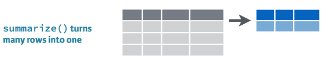

summarize()

- Verilerin özet istatistiklerinin oluşturulmasında `dplyr::summarize()` kullanılabilir.
- Bu komut öncesinde `group_by()` ile veriler gruplandırılarak grup istatistikleri oluşturulabilir.

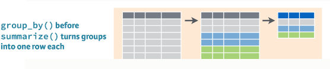

group_by()

- **Örnek**: 2007 yılında her bir kıtada kaç ülke var?

```r
gapminder |>
  filter(year==2007) |>
  group_by(continent) |>
  summarize(n = n())
```

```
## # A tibble: 5 × 2
##   continent     n
##   <fct>     <int>
## 1 Africa       52
## 2 Americas     25
## 3 Asia         33
## 4 Europe       30
## 5 Oceania       2
```

- **Örnek**: 2007 yılında kıtalara göre ortalama yaşam beklentisini ve ortalama kişi başına GDP değerini bulunuz.

```r
gapminder  |>
  filter(year==2007) |>
  group_by(continent) |>
  summarize(mean_life_exp = mean(lifeExp),
            mean_income = mean(gdpPercap))
```

```
## # A tibble: 5 × 3
##   continent mean_life_exp mean_income
##   <fct>             <dbl>       <dbl>
## 1 Africa             54.8       3089.
## 2 Americas           73.6      11003.
## 3 Asia               70.7      12473.
## 4 Europe             77.6      25054.
## 5 Oceania            80.7      29810.
```

- Kullanışlı diğer fonksiyonlar:
  - `summarize_at()`: belirli değişkenlerin özet istatistiklerini hesaplar
  - `summarize_all()`: tüm değişkenlerin özet istatistiklerini hesaplar.
  - `summarize_if()`: sadece bir tip değişkenlerin değerlerini hesaplar.
- **Örnek**: `summarize_at()` kullanımı:

```r
gapminder |>
  filter(year==2007) |>
  group_by(continent) |>
  summarize_at(vars(lifeExp, gdpPercap), mean)
```

```
## # A tibble: 5 × 3
##   continent lifeExp gdpPercap
##   <fct>       <dbl>     <dbl>
## 1 Africa       54.8     3089.
## 2 Americas     73.6    11003.
## 3 Asia         70.7    12473.
## 4 Europe       77.6    25054.
## 5 Oceania      80.7    29810.
```

- **Örnek**:

```r
gapminder |>
  filter(year==2007) |>
  group_by(continent) |>
  summarize_at(vars(lifeExp, gdpPercap), list(min = min, max = max))
```

```
## # A tibble: 5 × 5
##   continent lifeExp_min gdpPercap_min lifeExp_max gdpPercap_max
##   <fct>           <dbl>         <dbl>       <dbl>         <dbl>
## 1 Africa           39.6          278.        76.4        13206.
## 2 Americas         60.9         1202.        80.7        42952.
## 3 Asia             43.8          944         82.6        47307.
## 4 Europe           71.8         5937.        81.8        49357.
## 5 Oceania          80.2        25185.        81.2        34435.
```

**Örnek**: Önceki işlemi 1952 ve 2007 yılları için yapalım ve ortalamaları karşılaştıralım:

```r
gapminder |>
  filter(year %in% c(1952, 2007)) |>
  group_by(continent, year) |>
  summarize_at(vars(lifeExp, gdpPercap), mean)
```

```
## # A tibble: 10 × 4
## # Groups:   continent [5]
##    continent  year lifeExp gdpPercap
##    <fct>     <int>   <dbl>     <dbl>
##  1 Africa     1952    39.1     1253.
##  2 Africa     2007    54.8     3089.
##  3 Americas   1952    53.3     4079.
##  4 Americas   2007    73.6    11003.
##  5 Asia       1952    46.3     5195.
##  6 Asia       2007    70.7    12473.
##  7 Europe     1952    64.4     5661.
##  8 Europe     2007    77.6    25054.
##  9 Oceania    1952    69.3    10298.
## 10 Oceania    2007    80.7    29810.
```

Gruplamanın iki değişken üzerinden `group_by(continent, year)` yapıldığına dikkat ediniz.

- `summarise()` ile kullanılabiliecek fonksiyonlar aşağıda listelenmiştir. Bu fonksiyonların girdiden hareketle sadece bir özet istatistik verdiğine dikkat ediniz:
  - `n()`: satır (gözlem) sayısı
  - `n_distinct()`: farklı gözlem sayısı
  - `sum()`: toplam
  - `sum(!is.na())`: NA olmayan gözlem sayısı
  - `first()`: ilk değer
  - `last()`: son değer
  - `nth()`: n.nci sıradaki değer
  - `mean()`: örneklem ortalaması,
  - `median()`: medyan,
  - `var()`: örneklem varyansı,
  - `sd()`: örneklem standart sapması,
  - `mad()`: medyan mutlak hata (median absolute deviation),
  - `IQR()`: kartiller aralığı (interquartile range),
  - `min()`: minimum,
  - `max()`: maksimum
  - `quantile()`: n.nci dilim
- **Örnek**: Avrupa’da her yıl için minimum ve maksimum yaşam beklentisini bulunuz.

```r
gapminder |>
  filter(continent=="Europe") |>
  group_by(year) |>
  summarize(minlexp = min(lifeExp),
            maxlexp = max(lifeExp) )
```

```
## # A tibble: 12 × 3
##     year minlexp maxlexp
##    <int>   <dbl>   <dbl>
##  1  1952    43.6    72.7
##  2  1957    48.1    73.5
##  3  1962    52.1    73.7
##  4  1967    54.3    74.2
##  5  1972    57.0    74.7
##  6  1977    59.5    76.1
##  7  1982    61.0    77.0
##  8  1987    63.1    77.4
##  9  1992    66.1    78.8
## 10  1997    68.8    79.4
## 11  2002    70.8    80.6
## 12  2007    71.8    81.8
```

- `mutate()` ve `group_by()` fonksiyonlarının birlikte kullanılabilir:
- **Örnek**: Her ülke için kişi başına GDP değişkeninin başlangıç yılındaki değerine oranını gösteren yeni bir değişken oluşturunuz. Yeni değişken başlangıç yılı olan 1952’de 1 değerini almalı, diğer yıllar için başlangıç yılına göre (1+büyüme oranı) olmalı.

```r
gapminder |>
  group_by(country) |>
  select(country, year, gdpPercap) |>
  mutate(gdppc_to_first = gdpPercap/first(gdpPercap))
```

```
## # A tibble: 1,704 × 4
## # Groups:   country [142]
##    country      year gdpPercap gdppc_to_first
##    <fct>       <int>     <dbl>          <dbl>
##  1 Afghanistan  1952      779.          1
##  2 Afghanistan  1957      821.          1.05
##  3 Afghanistan  1962      853.          1.09
##  4 Afghanistan  1967      836.          1.07
##  5 Afghanistan  1972      740.          0.949
##  6 Afghanistan  1977      786.          1.01
##  7 Afghanistan  1982      978.          1.25
##  8 Afghanistan  1987      852.          1.09
##  9 Afghanistan  1992      649.          0.833
## 10 Afghanistan  1997      635.          0.815
## # ℹ 1,694 more rows
```

- **Örnek**: Yıldan yıla büyüme oranlarını yüzde olarak gösteren yeni bir değişken oluşturunuz.

```r
gapminder |>
  group_by(country) |>
  select(country, year, gdpPercap) |>
  mutate(gdppc_growth = 100*(gdpPercap-lag(gdpPercap))/lag(gdpPercap))
```

```
## # A tibble: 1,704 × 4
## # Groups:   country [142]
##    country      year gdpPercap gdppc_growth
##    <fct>       <int>     <dbl>        <dbl>
##  1 Afghanistan  1952      779.        NA
##  2 Afghanistan  1957      821.         5.31
##  3 Afghanistan  1962      853.         3.93
##  4 Afghanistan  1967      836.        -1.98
##  5 Afghanistan  1972      740.       -11.5
##  6 Afghanistan  1977      786.         6.23
##  7 Afghanistan  1982      978.        24.4
##  8 Afghanistan  1987      852.       -12.8
##  9 Afghanistan  1992      649.       -23.8
## 10 Afghanistan  1997      635.        -2.16
## # ℹ 1,694 more rows
```

Örnekte kullanılan `lag()` fonksiyonu bir önceki dönemdeki (yılda) değere eşit olan birinci gecikmedir. Gecikmeyi açıkça veri setine ekleyelim:

```r
gapminder |>
  group_by(country) |>
  select(country, year, gdpPercap) |>
  mutate(lag_gdppc = lag(gdpPercap, 1, order_by = year),
         gdppc_growth = 100*(gdpPercap-lag_gdppc)/lag_gdppc)
```

```
## # A tibble: 1,704 × 5
## # Groups:   country [142]
##    country      year gdpPercap lag_gdppc gdppc_growth
##    <fct>       <int>     <dbl>     <dbl>        <dbl>
##  1 Afghanistan  1952      779.       NA         NA
##  2 Afghanistan  1957      821.      779.         5.31
##  3 Afghanistan  1962      853.      821.         3.93
##  4 Afghanistan  1967      836.      853.        -1.98
##  5 Afghanistan  1972      740.      836.       -11.5
##  6 Afghanistan  1977      786.      740.         6.23
##  7 Afghanistan  1982      978.      786.        24.4
##  8 Afghanistan  1987      852.      978.       -12.8
##  9 Afghanistan  1992      649.      852.       -23.8
## 10 Afghanistan  1997      635.      649.        -2.16
## # ℹ 1,694 more rows
```

- Yukarıda **pipe** operatörünü kullandık. Bunu kullanmadan aynı kodu çalıştırmak istersek:

```r
mutate(select(group_by(gapminder,country), country, year, gdpPercap), gdppc_growth = 100*(gdpPercap-lag(gdpPercap))/lag(gdpPercap))
```

```
## # A tibble: 1,704 × 4
## # Groups:   country [142]
##    country      year gdpPercap gdppc_growth
##    <fct>       <int>     <dbl>        <dbl>
##  1 Afghanistan  1952      779.        NA
##  2 Afghanistan  1957      821.         5.31
##  3 Afghanistan  1962      853.         3.93
##  4 Afghanistan  1967      836.        -1.98
##  5 Afghanistan  1972      740.       -11.5
##  6 Afghanistan  1977      786.         6.23
##  7 Afghanistan  1982      978.        24.4
##  8 Afghanistan  1987      852.       -12.8
##  9 Afghanistan  1992      649.       -23.8
## 10 Afghanistan  1997      635.        -2.16
## # ℹ 1,694 more rows
```

Bunu okumanın daha zor olduğu açıktır.

- **Örnek**: Avrupa’da en düşük ve en yüksek yaşam beklentisini ülke bilgisiyle birlikte oluşturunuz. Önce, `europe` isimli yeni bir tibble yaratalım:

```r
europe <- gapminder |>
  filter(continent=="Europe") |>
  select(year, country, lifeExp)

europe |> head(10)
```

```
## # A tibble: 10 × 3
##     year country lifeExp
##    <int> <fct>     <dbl>
##  1  1952 Albania    55.2
##  2  1957 Albania    59.3
##  3  1962 Albania    64.8
##  4  1967 Albania    66.2
##  5  1972 Albania    67.7
##  6  1977 Albania    68.9
##  7  1982 Albania    70.4
##  8  1987 Albania    72
##  9  1992 Albania    71.6
## 10  1997 Albania    73.0
```

Daha sonra `min_rank()` ile yaşam beklentisini küçükten büyüğe doğru sıralayalım ve yeni bir değişken yaratarak sıralamaları kaydedelim. En düşük yaşam beklentisine sahip ilk iki ülkeyi listeleyelim:

```r
europe |>
  group_by(year) |>
  mutate(le_rank = min_rank(lifeExp)) |>
  filter(le_rank < 3) |>
  arrange(year)
```

```
## # A tibble: 24 × 4
## # Groups:   year [12]
##     year country                lifeExp le_rank
##    <int> <fct>                    <dbl>   <int>
##  1  1952 Bosnia and Herzegovina    53.8       2
##  2  1952 Turkey                    43.6       1
##  3  1957 Bosnia and Herzegovina    58.4       2
##  4  1957 Turkey                    48.1       1
##  5  1962 Bosnia and Herzegovina    61.9       2
##  6  1962 Turkey                    52.1       1
##  7  1967 Bosnia and Herzegovina    64.8       2
##  8  1967 Turkey                    54.3       1
##  9  1972 Bosnia and Herzegovina    67.4       2
## 10  1972 Turkey                    57.0       1
## # ℹ 14 more rows
```

Aynısını en yüksek yaşam beklentisi için yapalım:

```r
europe |> group_by(year) |>
  mutate(le_desc_rank = min_rank(desc(lifeExp))) |>
  filter(le_desc_rank < 3) |>
  arrange(year)
```

```
## # A tibble: 24 × 4
## # Groups:   year [12]
##     year country lifeExp le_desc_rank
##    <int> <fct>     <dbl>        <int>
##  1  1952 Iceland    72.5            2
##  2  1952 Norway     72.7            1
##  3  1957 Iceland    73.5            1
##  4  1957 Norway     73.4            2
##  5  1962 Iceland    73.7            1
##  6  1962 Norway     73.5            2
##  7  1967 Norway     74.1            2
##  8  1967 Sweden     74.2            1
##  9  1972 Iceland    74.5            2
## 10  1972 Sweden     74.7            1
## # ℹ 14 more rows
```

**Alıştırma**: Minimum ve maksimum yaşam beklentisini birlikte gösteren bir tablo oluşturunuz.

## 5.7 Veri setlerinin birleştirilmesi

- `table4a` ve `table4b` verilerini daha önce nasıl düzenli hale getireceğimizi görmmüştük. Şimdi bu iki veri setini birleştirelim.

```r
table4a
```

```
## # A tibble: 3 × 3
##   country     `1999` `2000`
##   <chr>        <dbl>  <dbl>
## 1 Afghanistan    745   2666
## 2 Brazil       37737  80488
## 3 China       212258 213766
```

```r
table4a_tidy <- pivot_longer(table4a,
                             cols = 2:3,
                             names_to = "year",
                             values_to = "cases")
table4a_tidy
```

```
## # A tibble: 6 × 3
##   country     year   cases
##   <chr>       <chr>  <dbl>
## 1 Afghanistan 1999     745
## 2 Afghanistan 2000    2666
## 3 Brazil      1999   37737
## 4 Brazil      2000   80488
## 5 China       1999  212258
## 6 China       2000  213766
```

```r
table4b_tidy <- pivot_longer(table4b,
                             cols = 2:3,
                             names_to = "year",
                             values_to = "population")
table4b_tidy
```

```
## # A tibble: 6 × 3
##   country     year  population
##   <chr>       <chr>      <dbl>
## 1 Afghanistan 1999    19987071
## 2 Afghanistan 2000    20595360
## 3 Brazil      1999   172006362
## 4 Brazil      2000   174504898
## 5 China       1999  1272915272
## 6 China       2000  1280428583
```

- Birleştirme için `dplyr::left_join()` fonksiyonu kullanılabilir:

```r
# country, year anahtarları ile birleştir
left_join(table4a_tidy, table4b_tidy, by = c("country", "year"))
```

```
## # A tibble: 6 × 4
##   country     year   cases population
##   <chr>       <chr>  <dbl>      <dbl>
## 1 Afghanistan 1999     745   19987071
## 2 Afghanistan 2000    2666   20595360
## 3 Brazil      1999   37737  172006362
## 4 Brazil      2000   80488  174504898
## 5 China       1999  212258 1272915272
## 6 China       2000  213766 1280428583
```

- Aşağıda listelenen birleştirme fonksiyonları (mutating joins) `veri2`’nin sütunlarını `veri1`’in sütunları ile belirli anahtar değerler yardımıyla eşleştirerek yeni sütunlar yaratır:
  - `left_join(veri1, veri2)`: `veri1`’in tüm satırlarını eşleştirir
  - `right_join(veri1, veri2)`: `veri2`’nin tüm satırlarını eşleştirir
  - `inner_join(veri1, veri2)`: her iki veri setinin eşleşen satırlarını muhafaza eder
  - `full_join(veri1, veri2)`: `veri1` ve `veri2`’nin tüm satırlarını muhafaza eder.

```r
veri1 <- tibble(id = c("Istanbul", "Istanbul", "Ankara", "Ankara", "Izmir", "Izmir"),
                year = c(2019, 2020, 2019, 2020,2019, 2020),
                x = c(50, 60, 30, 20, 40, NA))
veri1
```

```
## # A tibble: 6 × 3
##   id        year     x
##   <chr>    <dbl> <dbl>
## 1 Istanbul  2019    50
## 2 Istanbul  2020    60
## 3 Ankara    2019    30
## 4 Ankara    2020    20
## 5 Izmir     2019    40
## 6 Izmir     2020    NA
```

```r
veri2 <- tibble(id = c("Istanbul", "Istanbul", "Ankara", "Izmir", "Izmir", "Antalya"),
                year = c(2019, 2020, 2019, 2019, 2020, 2019),
                y = c(1000, 1200, 800, 600, 650, 500))
veri2
```

```
## # A tibble: 6 × 3
##   id        year     y
##   <chr>    <dbl> <dbl>
## 1 Istanbul  2019  1000
## 2 Istanbul  2020  1200
## 3 Ankara    2019   800
## 4 Izmir     2019   600
## 5 Izmir     2020   650
## 6 Antalya   2019   500
```

```r
# left_join() veri1'in satırlarını muhafaza eder, veri2'nin eşleşmeyen
# satırları alınmaz
left_join(veri1, veri2, by = c("id", "year"))
```

```
## # A tibble: 6 × 4
##   id        year     x     y
##   <chr>    <dbl> <dbl> <dbl>
## 1 Istanbul  2019    50  1000
## 2 Istanbul  2020    60  1200
## 3 Ankara    2019    30   800
## 4 Ankara    2020    20    NA
## 5 Izmir     2019    40   600
## 6 Izmir     2020    NA   650
```

```r
# right_join() veri2'nin satırlarını muhafaza eder
# eşleşmeyen satırlar = NA
right_join(veri1, veri2, by = c("id", "year"))
```

```
## # A tibble: 6 × 4
##   id        year     x     y
##   <chr>    <dbl> <dbl> <dbl>
## 1 Istanbul  2019    50  1000
## 2 Istanbul  2020    60  1200
## 3 Ankara    2019    30   800
## 4 Izmir     2019    40   600
## 5 Izmir     2020    NA   650
## 6 Antalya   2019    NA   500
```

```r
inner_join(veri1, veri2, by = c("id", "year"))
```

```
## # A tibble: 5 × 4
##   id        year     x     y
##   <chr>    <dbl> <dbl> <dbl>
## 1 Istanbul  2019    50  1000
## 2 Istanbul  2020    60  1200
## 3 Ankara    2019    30   800
## 4 Izmir     2019    40   600
## 5 Izmir     2020    NA   650
```

```r
full_join(veri1, veri2, by = c("id", "year"))
```

```
## # A tibble: 7 × 4
##   id        year     x     y
##   <chr>    <dbl> <dbl> <dbl>
## 1 Istanbul  2019    50  1000
## 2 Istanbul  2020    60  1200
## 3 Ankara    2019    30   800
## 4 Ankara    2020    20    NA
## 5 Izmir     2019    40   600
## 6 Izmir     2020    NA   650
## 7 Antalya   2019    NA   500
```

- `bind_cols()`: veri setlerinin sütunlarını oldukları gibi yan yana yapıştırır. Gözlemlerin (satırların) hizalanmış olması gerekir.
- `bind_rows()`: veri setlerinin satırlarını (gözlemleri) alt alta yapıştırır. Sütunların hizalanmış olması gerekir. Yeni gözlemlerin eklenmesi için kullanılabilir.
- **Alıştırma**: Aşağıdaki tabloyu `veri1` ve `veri2` tablolarıyla nasıl birleştirirsiniz? `veri3`’ün yeni satırlar içerdiğine dikkat ediniz.

```r
veri3 <- tibble(id = c("Bursa", "Bursa", "Adana", "Adana"),
                year = c(2019, 2020, 2019, 2020),
                x = c(110, 115, 160, 140),
                y = c(350, 380, 440, 430))
veri3
```

```
## # A tibble: 4 × 4
##   id     year     x     y
##   <chr> <dbl> <dbl> <dbl>
## 1 Bursa  2019   110   350
## 2 Bursa  2020   115   380
## 3 Adana  2019   160   440
## 4 Adana  2020   140   430
```

- **Çözüm**

```r
veri1 |> full_join(veri2) |>
  bind_rows(veri3)
```

```
## # A tibble: 11 × 4
##    id        year     x     y
##    <chr>    <dbl> <dbl> <dbl>
##  1 Istanbul  2019    50  1000
##  2 Istanbul  2020    60  1200
##  3 Ankara    2019    30   800
##  4 Ankara    2020    20    NA
##  5 Izmir     2019    40   600
##  6 Izmir     2020    NA   650
##  7 Antalya   2019    NA   500
##  8 Bursa     2019   110   350
##  9 Bursa     2020   115   380
## 10 Adana     2019   160   440
## 11 Adana     2020   140   430
```

## 5.8 Diğer fonksiyonlar

### 5.8.1 `rename()`

- Mevcut değişkenleri yeniden isimlendirir.

```r
gapminder |> filter(country == "Turkey") |>
  rename(life_exp = lifeExp,
         gdp_pc = gdpPercap
         )
```

```
## # A tibble: 12 × 6
##    country continent  year life_exp      pop gdp_pc
##    <fct>   <fct>     <int>    <dbl>    <int>  <dbl>
##  1 Turkey  Europe     1952     43.6 22235677  1969.
##  2 Turkey  Europe     1957     48.1 25670939  2219.
##  3 Turkey  Europe     1962     52.1 29788695  2323.
##  4 Turkey  Europe     1967     54.3 33411317  2826.
##  5 Turkey  Europe     1972     57.0 37492953  3451.
##  6 Turkey  Europe     1977     59.5 42404033  4269.
##  7 Turkey  Europe     1982     61.0 47328791  4241.
##  8 Turkey  Europe     1987     63.1 52881328  5089.
##  9 Turkey  Europe     1992     66.1 58179144  5678.
## 10 Turkey  Europe     1997     68.8 63047647  6601.
## 11 Turkey  Europe     2002     70.8 67308928  6508.
## 12 Turkey  Europe     2007     71.8 71158647  8458.
```

### 5.8.2 `relocate()`

- Sütunların konumunu değiştirir, satırları etkilemez ve grupları değiştirmez.

```r
gapminder |> filter(country == "Turkey") |>
  rename(life_exp = lifeExp,
         gdp_pc = gdpPercap
         ) |>
  relocate(gdp_pc, .after = year)
```

```
## # A tibble: 12 × 6
##    country continent  year gdp_pc life_exp      pop
##    <fct>   <fct>     <int>  <dbl>    <dbl>    <int>
##  1 Turkey  Europe     1952  1969.     43.6 22235677
##  2 Turkey  Europe     1957  2219.     48.1 25670939
##  3 Turkey  Europe     1962  2323.     52.1 29788695
##  4 Turkey  Europe     1967  2826.     54.3 33411317
##  5 Turkey  Europe     1972  3451.     57.0 37492953
##  6 Turkey  Europe     1977  4269.     59.5 42404033
##  7 Turkey  Europe     1982  4241.     61.0 47328791
##  8 Turkey  Europe     1987  5089.     63.1 52881328
##  9 Turkey  Europe     1992  5678.     66.1 58179144
## 10 Turkey  Europe     1997  6601.     68.8 63047647
## 11 Turkey  Europe     2002  6508.     70.8 67308928
## 12 Turkey  Europe     2007  8458.     71.8 71158647
```

```r
gapminder |> filter(country == "Turkey") |>
  rename(life_exp = lifeExp,
         gdp_pc = gdpPercap
         ) |>
  relocate(gdp_pc, .before = life_exp)
```

```
## # A tibble: 12 × 6
##    country continent  year gdp_pc life_exp      pop
##    <fct>   <fct>     <int>  <dbl>    <dbl>    <int>
##  1 Turkey  Europe     1952  1969.     43.6 22235677
##  2 Turkey  Europe     1957  2219.     48.1 25670939
##  3 Turkey  Europe     1962  2323.     52.1 29788695
##  4 Turkey  Europe     1967  2826.     54.3 33411317
##  5 Turkey  Europe     1972  3451.     57.0 37492953
##  6 Turkey  Europe     1977  4269.     59.5 42404033
##  7 Turkey  Europe     1982  4241.     61.0 47328791
##  8 Turkey  Europe     1987  5089.     63.1 52881328
##  9 Turkey  Europe     1992  5678.     66.1 58179144
## 10 Turkey  Europe     1997  6601.     68.8 63047647
## 11 Turkey  Europe     2002  6508.     70.8 67308928
## 12 Turkey  Europe     2007  8458.     71.8 71158647
```

### 5.8.3 `distinct()`

- Tekrar eden satırları siler.

```r
df <- tibble(x = c(1:5, 5),
             y = c(11:15, 15),
             z = c(letters[1:5], "e"))
df
```

```
## # A tibble: 6 × 3
##       x     y z
##   <dbl> <dbl> <chr>
## 1     1    11 a
## 2     2    12 b
## 3     3    13 c
## 4     4    14 d
## 5     5    15 e
## 6     5    15 e
```

```r
# distinct gözlem sayısı
nrow(distinct(df))
```

```
## [1] 5
```

```r
# distinct gözlemler
df |> distinct()
```

```
## # A tibble: 5 × 3
##       x     y z
##   <dbl> <dbl> <chr>
## 1     1    11 a
## 2     2    12 b
## 3     3    13 c
## 4     4    14 d
## 5     5    15 e
```

# 6 `{ggplot2}` Paketi ile Görselleştirme

- `{ggplot2}` verilerin görselleştirilmesinde **grafiklerin grameri** (grammar of graphics) yaklaşımını benimser.
- Hadley Wickham tarafından geliştirilmiş bir R kütüphanesi olan `{ggplot2}` Tidyverse meta-paketinin bir parçasıdır. Dolayısıyla `library(tidyverse)` komutuyla otomatik olarak aktif hale gelir.
- Eğer diğer bileşenlerini istemiyorsak `{ggplot2}` paketini bağımsız olarak da çağırabiliriz:

```r
library(ggplot2)
```

- `{ggplot2}` bir grafiği, veri, geometrik şekiller, renkler, haritalama, istatistik, konum, koordinat sistemi ve fasetlerin katmanlar halinde kullanılmasıyla oluşturur.
- Tipik bir grafik için şablon aşağıdaki gibi yazılabilir:

```r
ggplot(data = <DATA>) +
  <GEOM_FUNCTION>(
     mapping = aes(<MAPPINGS>),
     stat = <STAT>,
     position = <POSITION>
  ) +
  <COORDINATE_FUNCTION> +
  <FACET_FUNCTION>
```

- `ggplot2` ile ilgili temel kaynaklar:
  - [Hadley Wickham ve Garret Grolemund, R for Data Science, Data Visualization with ggplot2](https://r4ds.had.co.nz/data-visualisation.html)
  - [Hadley Wickham, ggplot2: Elegant Graphics for Data Analysis](https://ggplot2-book.org/)
  - [Winston Chang, R Graphics Cookbook: Practical Recipes for Visualizing Data](http://www.cookbook-r.com/Graphs/)